# Examen du 9 janvier 2026 (3H)

## Exercice 1

Voici le modèle relationnel du SI d’une médiathèque.

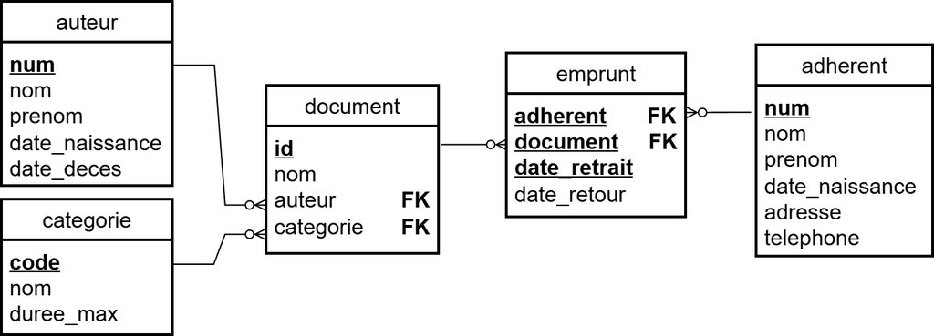

Ce SI enregistrent les emprunts de documents par les adhérents de la médiathèque. Les documents sont de plusieurs catégories (`livre`, `BD`, `CD`, `DVD`). Chaque catégorie a une durée d’emprunt maximum spécifique exprimée en jours.

- Les attributs `auteur.num`, `categorie.code`, `document.id` et `adherent.num` sont des entiers ainsi que les attributs qui les référencent.
- Les attributs `emprunt.date_retrait`, `emprunt.date_retour` sont de type `DATE` et stockent les dates de retrait et de retour d’un emprunt de document par un adhérent. **Lorsqu’un document n’est pas encore rendu**, l’attribut `emprunt.date_retour` est vide.
- Les attributs `auteur.date_naissance`, `auteur.date_deces` et `adherent.date_naissance` sont de type `DATE`.
- L’attribut `categorie.duree_max` est un entier qui stocke le nombre de jours maximum d’un emprunt pour un document de la catégorie.

### Questions

1. Écrire en SQL la requête de définition de la table `emprunt` en tenant compte du modèle relationnel et des indications précédentes.
2. Écrire en SLQ une requête qui liste les noms des documents dont l’auteur est `Jules Verne`.
3. Écrire en SLQ une requête qui liste pour chaque auteur, le nombre de documents présents dans la médiathèque. On indiquera sur chaque ligne, le numéro de l’auteur, le nom de l’auteur et le nombre de documents.
4. Écrire en SLQ une requête qui liste toutes les informations des adhérents qui ont emprunté au moins un document qui n’a pas encore été rendu. Chaque adhérent ne doit apparaître qu’une fois.
5. Écrire en SQL une requête qui liste les `id` des documents de la catégorie nommée `BD` qui ont été empruntés au moins 10 fois.
6. Écrire en SQL une requête qui liste les numéros des adhérents qui n’ont jamais emprunté le document dont l’`id` est `200`.
7. Écrire en SQL une requête qui donne, pour chaque catégorie, le nombre moyen d’emprunts par document durant l’année 2025. Sur chaque ligne, on indiquera seulement le code de la catégorie et le nombre moyen.

   **Indication** : l’expression `emprunt.date_retrait BETWEEN '2025-01-01' AND '2025-12-31'` permet de tester si un emprunt a été fait durant l’année 2025.
8. Écrire en SQL, sans sous-requête, sans CTE (sans `WITH`) et sans INTERSECT, une requête qui liste les numéros des adhérents qui ont emprunté au moins une fois le document d’`id` `100` **et** au moins une fois celui d’`id` `200`. Un numéro d’adhérent ne doit apparaître au plus qu’une fois.
9. Écrire en SQL une requête qui indique le document emprunté par le plus grand nombre d’adhérents différents.
10. (**BONUS**) Expliquer pourquoi l’attribut `emprunt.date_retrait` fait partie de l’identifiant de la relation `emprunt`.

## Exercice 2

On veut concevoir une base de données pour gérer des réservations de courts de tennis par les membres d’un club de sport.

Doivent être enregistrés dans la base :

- les membres du club avec un numéro unique, un nom, un prénom.
- les entraîneurs du club avec un numéro unique, un nom, un prénom.
- les installations avec un numéro unique, un nom, un type d’installation.
- les types d’installation (court intérieur, court extérieur, trainer, etc.) avec un code unique, un nom, une description.

La future interface de saisie d’une réservation se présentera ainsi :

- Saisie du numéro de membre.
- Saisie de la date-heure et de la durée de la réservation souhaitée.
- Saisie du type d’installation souhaité. Après de la saisie de ce champ, le système affichera les installations disponibles pour le type souhaité dans la plage horaire demandée et **le membre choisira une installation**. Si aucune installation n’est choisie ou n’est disponible, la réservation ne sera pas créée.
- Saisie de la demande d’un entraîneur : “oui/non”. Si le membre répond “oui”, le système affichera la liste des entraîneurs disponibles avec leurs tarifs horaires et **le membre choisira un entraîneur**. Si aucun entraîneur n’est choisi ou n’est disponible, la réservation ne sera pas créée à moins de répondre “non” à la demande d’un entraîneur.

Le **tarif horaire d’un entraîneur** dépend de l’entraîneur et du type d’installation sur laquelle il intervient.

### Questions

1. Écrire, en modélisant les réservations par une entité, un diagramme E/A pour ce SI. Indiquer les cardinalités et justifier les cardinalités qui ajoutent une contrainte au modèle.
2. Écrire, en modélisant les réservations sans utiliser une entité, un diagramme E/A avancé pour ce SI. Indiquer les cardinalités (pas de justification demandée). Vérifier qu’un membre puisse réserver plusieurs fois la même installation. Ajouter si nécessaire des contraintes au diagramme.

## Exercice 3

On veut créer une BDD pour enregistrer les RV d’une clinique médicale.

L’équipe de conception a élaboré le MCD suivant :

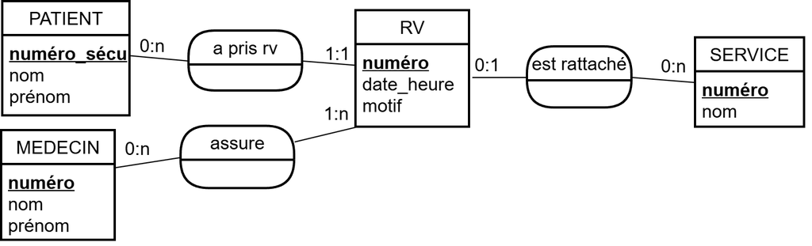

Indications complémentaires :

- dans certains cas particuliers, un RV nécessite la présence de plusieurs médecins.
- certains RV sont rattachés à un service, d’autres non.

### Questions

1. Convertir ce diagramme E/A en un modèle relationnel. Pas de justifications demandées.
2. Quelles sont les clés étrangères sur lesquelles il faudra ajouter une contrainte `NOT NULL` ou `UNIQUE` lors de la définition des tables en SQL ? Justifier.

## Exercice 4

L’étude d’un SI a conduit à ce diagramme des DF :

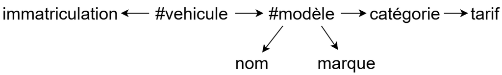

L’équipe de conception vous a fourni ce schéma relationnel :

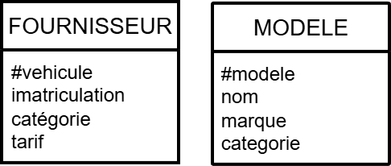

### Questions

1. Déterminer si ce schéma relationnel entraîne des pertes de DF.
2. Pour chaque relation de ce schéma, déterminer les clés et vérifier si la relation est en FNBC, sinon donner la forme normale optimale qu’elle vérifie.
3. Pour les tables qui ne sont pas FNBC, illustrer les redondances par des exemples de tuples.

## Exercice 5

Voici le diagramme des DF d’un SI :

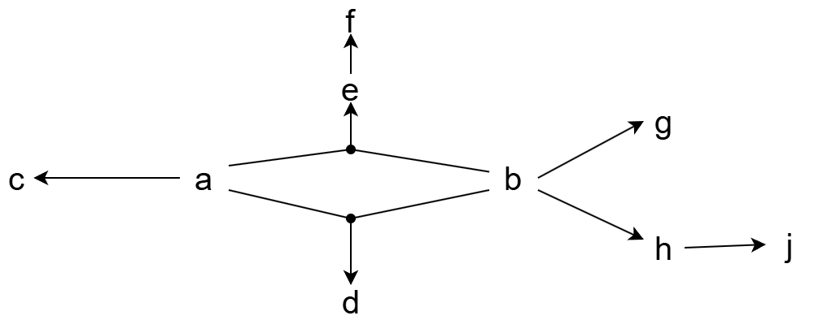

### Questions

1. Proposer un schéma en FN3 pour ce SI.
2. Montrer que ce schéma est en FN3.
3. Ce schéma est-il en FNBC ? Justifier.